# Bayesian-networks

### 2. Ramen Reviews

This dataset contains over 2000 reviews for different instant ramen soups. The goal I set was to try and estimate review score based on the other features. However this dataset is very dirty and very basic so it will require some cleaning and feature extraction to be more useable. Let’s take a look at the data.

```r
ramen_reviews <- read.csv("data/ramen-ratings.csv")
summary(ramen_reviews)
```

```
##     Review..           Brand                    Variety         Style
##  Min.   :   1.0   Nissin  : 381   Beef              :   7   Pack   :1531
##  1st Qu.: 645.8   Nongshim:  98   Chicken           :   7   Bowl   : 481
##  Median :1290.5   Maruchan:  76   Artificial Chicken:   6   Cup    : 450
##  Mean   :1290.5   Mama    :  71   Vegetable         :   6   Tray   : 108
##  3rd Qu.:1935.2   Paldo   :  66   Yakisoba          :   6   Box    :   6
##  Max.   :2580.0   Myojo   :  63   Miso Ramen        :   5          :   2
##                   (Other) :1825   (Other)           :2543   (Other):   2
##         Country         Stars         Top.Ten
##  Japan      : 352   4      :384           :2539
##  USA        : 323   5      :369   \n      :   4
##  South Korea: 309   3.75   :350   2012 #1 :   1
##  Taiwan     : 224   3.5    :326   2012 #10:   1
##  Thailand   : 191   3      :173   2012 #2 :   1
##  China      : 169   3.25   :170   2012 #3 :   1
##  (Other)    :1012   (Other):808   (Other) :  33
```

As we can see, there are few useless columns like review number or Top Ten rating. There are also a few other noteworthy columns:

```r
ramen_reviews <- read.csv("data/ramen-ratings.csv")
summary(ramen_reviews$Stars)
```

```
##       0     0.1    0.25     0.5    0.75     0.9       1     1.1    1.25
##      26       1      11      14       1       1      26       2      10
##     1.5    1.75     1.8       2     2.1   2.125    2.25     2.3     2.5
##      37      27       1      68       1       1      21       2      67
##    2.75     2.8    2.85     2.9       3     3.0    3.00     3.1   3.125
##      85       2       1       2     173       2       1       2       1
##     3.2    3.25     3.3     3.4     3.5    3.50     3.6    3.65     3.7
##       1     170       1       1     326       9       1       1       1
##    3.75     3.8       4     4.0    4.00   4.125    4.25     4.3     4.5
##     350       3     384       3       6       2     143       4     132
##    4.50    4.75       5     5.0    5.00 Unrated
##       3      64     369      10       7       3
```

If we take a closer look at Stars column, we find out that in addition to having 3 NA values (“Unrated” in this case), we also find out that despite the rating being in stars, there are a lot of fractions which will require us to group some of the ratings together. Additionally we can see that the ratings are heavily skewed towards 3 and 4 which we will have to keep in mind when grouping ratings together.

### 3. Student Performance

This dataset targets relationships of demographic, social and school related features with student’s school grades. Data have been collected from two Portuguese schools. From two subjects, math has been chosen for the classification. The dataset, originally, contains each student’s final grade, which will be divided into two intervals of passing and not passing students. According to Portuguese grading system, a student passes (the grade meets requirements fot the student to pass the year), if the final grade is above or equal 10.  
The dataset reference is located at https://archive.ics.uci.edu/ml/datasets/Student+Performance

Due to higher total count of features, selected features are:  
1. reason - reason to choose this school (nominal: close to ‘home’, school ‘reputation’, ‘course’ preference or ‘other’)  
2. studytime - weekly study time (numeric: 1 - <2 hours, 2 - 2 to 5 hours, 3 - 5 to 10 hours, or 4 - >10 hours)  
3. failures - number of past class failures (numeric: n if 1<=n<3, else 4)  
4. paid - extra paid classes within the course subject (Math or Portuguese) (binary: yes or no)  
5. higher - wants to take higher education (binary: yes or no)  
6. romantic - with a romantic relationship (binary: yes or no)  
7. famrel - quality of family relationships (numeric: from 1 - very bad to 5 - excellent)  
8. freetime - free time after school (numeric: from 1 - very low to 5 - very high)  
9. goout - going out with friends (numeric: from 1 - very low to 5 - very high)  
10. absences - number of school absences (numeric: from 0 to 93)  
11. Dalc - workday alcohol consumption (numeric: from 1 - very low to 5 - very high)

The class feature “passed” has been created by determining, from final grade (feature “G3”), whether the student passed or not.

## 3. Preprocessing

### 1. German Credit Data

Since this dataset contains a lot of NA values, lets get rid of it with function mice

```r
# Number of NA values
sum(is.na(german_credit_data))
```

```
## [1] 577
```

```r
# First 5 NA values
head(german_credit_data[, c(5,6)])
```

```
##   Saving.accounts Checking.account
## 1            <NA>           little
## 2          little         moderate
## 3          little             <NA>
## 4          little           little
## 5          little           little
## 6            <NA>             <NA>
```

```r
german_credit_data <- complete(mice(german_credit_data))
sum(is.na(german_credit_data))
```

```
## [1] 0
```

```r
head(german_credit_data[, c(5,6)])
```

```
##   Saving.accounts Checking.account
## 1          little           little
## 2          little         moderate
## 3          little           little
## 4          little           little
## 5          little           little
## 6          little           little
```

Apparantly this dataset is unballanced(has unequal number of instances for different classes)

```r
table(german_credit_data$Risk)
```

```
##
##  bad good
##  300  700
```

Using function ovun.sample to ballance the data It creates possibly balanced samples by combination of random over-sampling minority examples and under-sampling majority examples. Over/Under sampling whole dataset would create copies of the same point. It may end up in both the training and test sets. This allows the classifier to cheat. Firstly I will divide the dataset to train/test and over/under sample just the train one.

```r
set.seed(123)
indicies <- createDataPartition(german_credit_data$Risk, p = 0.6, list=FALSE)
german_credit_train <- german_credit_data[indicies, ]
german_credit_test <- german_credit_data[-indicies, ]
train_balanced_german_data <- ovun.sample(Risk ~., data=german_credit_train)$data
table(train_balanced_german_data$Risk)
```

```
##
## good  bad
##  299  301
```

Test data are still unbalanced but not really much to do with it.

```r
table(german_credit_test$Risk)
```

```
##
##  bad good
##  120  280
```

### 2. Ramen Reviews

First of all we remove rows with missing rating and rows where Style column contains invalid, missing or very rare values. Since there are very few of them we can afford to just remove them.

```r
ramen_reviews <- read.csv("data/ramen-ratings.csv")

#remove unrated entries
ramen_reviews <- ramen_reviews[ramen_reviews$Stars != "Unrated", ]

#remove entries with invalid or infrequent Style
ramen_reviews$Style <- fct_lump(ramen_reviews$Style, n=4)
ramen_reviews <- ramen_reviews[ramen_reviews$Style != "Other" ,]
```

Now we extract features from text description (“Variety” column)

```r
#extracting features from "Variety"
ramen_reviews$Beef <- grepl("(\\b|\\w)(beef|bo|gomtang|gomguk)(\\b|\\w)", ramen_reviews$Variety, ignore.case=TRUE, perl=TRUE)
ramen_reviews$Pork <- grepl("(\\b|\\w)(pork|tonkotsu|myeon|myun)(\\b|\\w)", ramen_reviews$Variety, ignore.case=TRUE, perl=TRUE)
ramen_reviews$Chicken <- grepl("(\\b|\\w)(Bird|ga|chicken|duck|kung|gung|laksa|chikin)(\\b|\\w)", ramen_reviews$Variety, ignore.case=TRUE, perl=TRUE)
ramen_reviews$Vegetable <- grepl("(\\b|\\w)(Vegetable|mushroom|vegetarian|tomato|onion|veggie|shroom|radish)(\\b|\\w)", ramen_reviews$Variety, ignore.case=TRUE, perl=TRUE)
ramen_reviews$Miso <- grepl("(\\b|\\w)(miso)(\\b|\\w)", ramen_reviews$Variety, ignore.case=TRUE, perl=TRUE)
ramen_reviews$WheatNoodles <- grepl("(\\b|\\w)(udon|wheat|oat|udoin|tempura|soba|u-dong)(\\b|\\w)", ramen_reviews$Variety, ignore.case=TRUE, perl=TRUE)
ramen_reviews$Spicy <- grepl("(\\b|\\w)(hot|kimchi|spicy|pepper|yung|yum|masala|laksa|chili|chilli|curry|spice)(\\b|\\w)", ramen_reviews$Variety, ignore.case=TRUE, perl=TRUE)
ramen_reviews$Seafood <- grepl("(\\b|\\w)(sea|food|crab|cua|fish|tom|seafood|oyster|shrimp|scallop|mentaiko|myeongnan|myeong|pollack|pollock|clam|prawn)(\\b|\\w)", ramen_reviews$Variety, ignore.case=TRUE, perl=TRUE)
ramen_reviews$Sesame <- grepl("(\\b|\\w)(sesame)(\\b|\\w)", ramen_reviews$Variety, ignore.case=TRUE, perl=TRUE)
ramen_reviews$RiceNoodles <- grepl("(\\b|\\w)(Rice|pad)(\\b|\\w)", ramen_reviews$Variety, ignore.case=TRUE, perl=TRUE)
ramen_reviews$Soy <- grepl("(\\b|\\w)(soy|shio|shoyu)(\\b|\\w)", ramen_reviews$Variety, ignore.case=TRUE, perl=TRUE)
ramen_reviews$StirFried <- grepl("(\\b|\\w)(stir|fried|stirfried|goreng|pad)(\\b|\\w)", ramen_reviews$Variety, ignore.case=TRUE, perl=TRUE)
ramen_reviews$Creamy <- grepl("(\\b|\\w)(creamy|cream)(\\b|\\w)", ramen_reviews$Variety, ignore.case=TRUE, perl=TRUE)
ramen_reviews$Oriental <- grepl("(\\b|\\w)(oriental)(\\b|\\w)", ramen_reviews$Variety, ignore.case=TRUE, perl=TRUE)

#remove all ramen that we weren't able to extract any features from
ramen_reviews <- ramen_reviews[rowSums(sapply(ramen_reviews[,c(8:21)], identity))!=0,]
```

Finally we clean up Star rating and transform numerical score into four categories. Then we clump infrequent values in Country and Brand to “Other”. Lastly we remove obsoleted columns and drop unused levels from factors.

```r
#clumping infrequent countries of origin and brands together
ramen_reviews$Country <- fct_lump(ramen_reviews$Country, prop=0.02)
ramen_reviews$Brand <- fct_lump(ramen_reviews$Brand, prop=0.02)

#clean up factors by dropping unused levels
ramen_reviews <- droplevels(ramen_reviews)

#group stars into four categories
rrf <- factor(c("bad", "average", "good", "great"))
rr4 <- (subset(ramen_reviews, grepl("^(5|4.5|4.7)", Stars, ignore.case=TRUE, perl=TRUE)))
rr4$Rating <- rrf[4]
rr3 <- (subset(ramen_reviews, grepl("^(4$|4.0|4.1|4.2|4.3)", Stars, ignore.case=TRUE, perl=TRUE)))
rr3$Rating <- rrf[3]
rr2 <- (subset(ramen_reviews, grepl("^(3.5|3.6|3.7|3.8)", Stars, ignore.case=TRUE, perl=TRUE)))
rr2$Rating <- rrf[2]
rr1 <- (subset(ramen_reviews, grepl("^(0|1|2|3$|3.0|3.1|3.2|3.3|3.4)", Stars, ignore.case=TRUE, perl=TRUE)))
rr1$Rating <- rrf[1]
ramen_reviews <- rbind(rr3, rr4, rr2, rr1)

#removing useless or obsoleted columns
ramen_reviews <- subset(ramen_reviews, select = -c(Variety, Stars, Top.Ten, Review..))
```

### 3. Student Performance

```r
student_performance = read.csv2("data/student-mat.csv")

# grade categorization
student_performance$passed = cut(student_performance$G3, labels = c("N", "P"), breaks = seq(0, 20, by = 10), right = FALSE)

# omitting NAs and selecting desired columns
student_performance = na.omit(student_performance)[, c("reason", "studytime", "failures", "paid", "higher", "romantic", "famrel", "freetime", "goout", "absences", "Dalc", "passed")]

# translating some feature values from ints to more understandable form
student_performance$studytime[student_performance$studytime == "1"] = "less_than_2_hours"
student_performance$studytime[student_performance$studytime == "2"] = "2_to_5_hours"
student_performance$studytime[student_performance$studytime == "3"] = "5_to_10_hours"
student_performance$studytime[student_performance$studytime == "4"] = "more_than_10_hours"

# omitting unused feature values (e.g. failures: "4")
student_performance = droplevels(student_performance)
```

## 4. Learning Algorithms

### 1. Bayesian Generalized Linear Model

The generalized linear model (GLM) is a flexible generalization of ordinary linear regression that allows for response variables that have error distribution models other than a normal distribution. The GLM generalizes linear regression by allowing the linear model to be related to the response variable via a link function and by allowing the magnitude of the variance of each measurement to be a function of its predicted value.

The GLM consists of three elements:

1. An exponential family of probability distributions.
2. A linear predictor η = Xβ .
3. A link function g such that E(Y|X) = μ = g−1(η).

### 2. Bayesian Averaged One Dependency Estimator (AODE)

AODE works similarly to naive Bayes however it avoids assuming feature independence. For dataset with n features AODE creates n models where each model assumes that i-th feature is dependent on all other features while all other features are independent of each other. Thus it can model up to quadratic dependencies accurately. Result returned by AODE is a simple average of all n models.

## 5. Evaluation

### 1. Bayesian Generalized Linear Model

I’v made a function that performs the training process multiple times so the random paritioning doesn’t effect the process.

iterations - number of iterations, splitPercantage - the train/test partition ratio

```r
set.seed(123)
germanEvaluation <- function(iterations, splitPercentage ) {
  accuracies <- numeric(iterations)
  for (i in 1:iterations) {
    # I have created the partition train/test before in the preprocess section but it was just for explain purposes.
    # Now its partitioned again in every iteration in cycle.
    # The same holds for balancing the data.
    indicies <- createDataPartition(german_credit_data$Risk, p = splitPercentage, list=FALSE)
    german_credit_train <- german_credit_data[indicies, ]
    german_credit_test <- german_credit_data[-indicies, ]
    train_balanced_german_data <- ovun.sample(Risk ~., data=german_credit_train)$data

    bayesglm_german_credit_model <- train(Risk ~., data=train_balanced_german_data, method="bayesglm",
                                          trControl = trainControl(method = "cv", number=3))

    bayesglm_german_credit_prediction <- predict(bayesglm_german_credit_model, german_credit_test)
    conf <- suppressWarnings(confusionMatrix(bayesglm_german_credit_prediction, german_credit_test$Risk))
    accuracies[i] <- conf$overall['Accuracy']
    cat("-", sep="") # just to see the progress of training
  }
  cat("\n")
  cat("Best accuracy for split ratio" , splitPercentage, " : ", max(accuracies))
  accuracies
}
eval1 <- germanEvaluation(30, 0.7)
```

```
## ------------------------------
## Best accuracy for split ratio 0.7  :  0.7033333
```

```r
eval2 <- germanEvaluation(30, 0.95)
```

```
## ------------------------------
## Best accuracy for split ratio 0.95  :  0.74
```

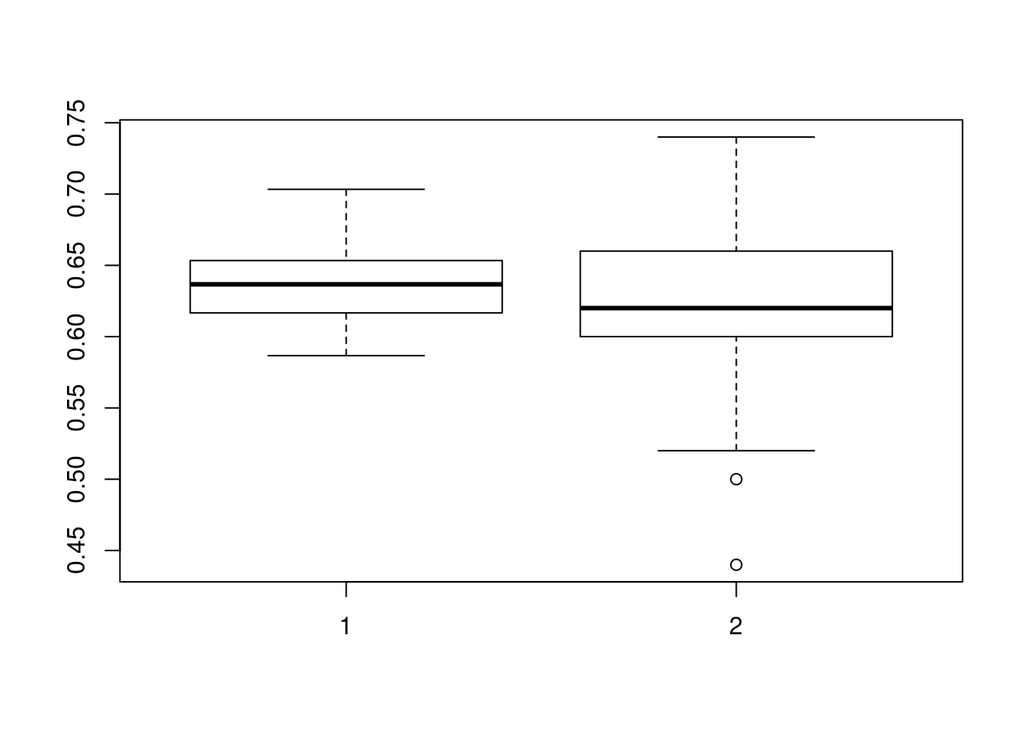

```r
boxplot(eval1, eval2)
```

### 2. AODE

#### 1. German Credit Data

```r
set.seed(123)
aode_german_evaluation <- function(iterations, splitPercentage ) {
  accuracies <- numeric(iterations)
  for (i in 1:iterations) {
    indicies <- createDataPartition(german_credit_data$Risk, p = splitPercentage, list=FALSE)
    german_credit_train <- german_credit_data[indicies, ]
    german_credit_test <- german_credit_data[-indicies, ]

    aode_german_credit_model <- aode(german_credit_train)

    aode_german_credit_prediction <- predict(aode_german_credit_model, german_credit_test)
    conf <- table(aode_german_credit_prediction, german_credit_test$Risk)
    accuracies[i] <- ((conf[1,1] + conf[2,2])/length(aode_german_credit_prediction))
    cat("-", sep="") # just to see the progress of training
  }
  cat("\n")
  cat("Best accuracy for split ratio" , splitPercentage, " : ", max(accuracies), "\n")
  accuracies
}
aode_ger_eval1 <- aode_german_evaluation(30, 0.7)
```

```
## ------------------------------
## Best accuracy for split ratio 0.7  :  0.72
```

```r
aode_ger_eval2 <- aode_german_evaluation(30, 0.95)
```

```
## ------------------------------
## Best accuracy for split ratio 0.95  :  0.76
```

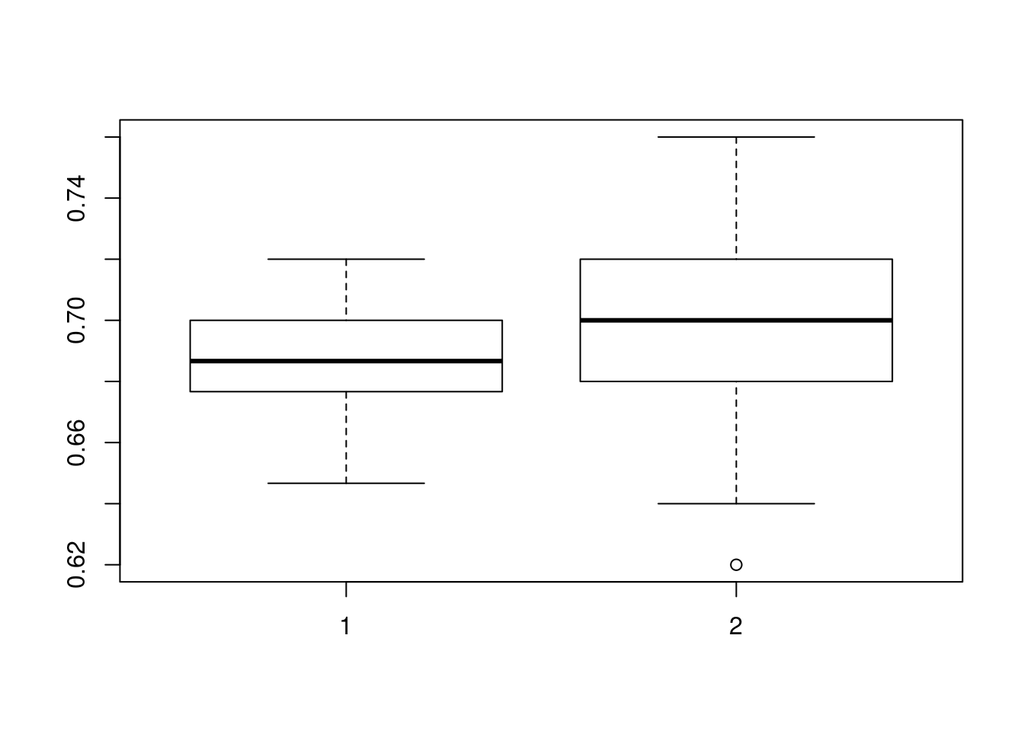

```r
boxplot(aode_ger_eval1, aode_ger_eval2)
```

#### 2. Ramen Reviews

Since the classes of Rating are balanced and are ordered, it would be best to use evaluation methods based on distance from the correct class. In this case we will use analogy of MSE (all classes will be considered 1 unit away from their neighbours)

```r
#table = confusion matrix, n = number of instances of test data
ramen_squared_error <- function(table, n) {
  error <- 0
  for (i in 1:4) {
    for (j in 1:4) {
      #print(error)
      #print(table[i,j])
      error <- (error + (table[i,j] * abs(i - j)))
    }
  }
  error <- error / n
  error
}

set.seed(123)
aode_ramen_evaluation <- function(iterations, splitPercentage ) {
  errors <- numeric(iterations)
  for (i in 1:iterations) {
    indicies <- createDataPartition(ramen_reviews$Rating, p = splitPercentage, list=FALSE)
    ramen_train <- ramen_reviews[indicies, ]
    ramen_test <- ramen_reviews[-indicies, ]

    aode_ramen_model <- aode(ramen_train)

    aode_ramen_prediction <- predict(aode_ramen_model, ramen_test)
    conf <- table(aode_ramen_prediction, ramen_test$Rating)
    errors[i] <- ramen_squared_error(conf, length(aode_ramen_prediction))
    cat("-", sep="") # just to see the progress of training
  }
  cat("\n")
  cat("Best error for split ratio" , splitPercentage, " : ", min(errors), "\n")
  errors
}
aode_ramen_eval1 <- aode_ramen_evaluation(15, 0.7)
```

```
## ---------------
## Best error for split ratio 0.7  :  1.061162
```

```r
aode_ramen_eval2 <- aode_ramen_evaluation(15, 0.95)
```

```
## ---------------
## Best error for split ratio 0.95  :  1.240741
```

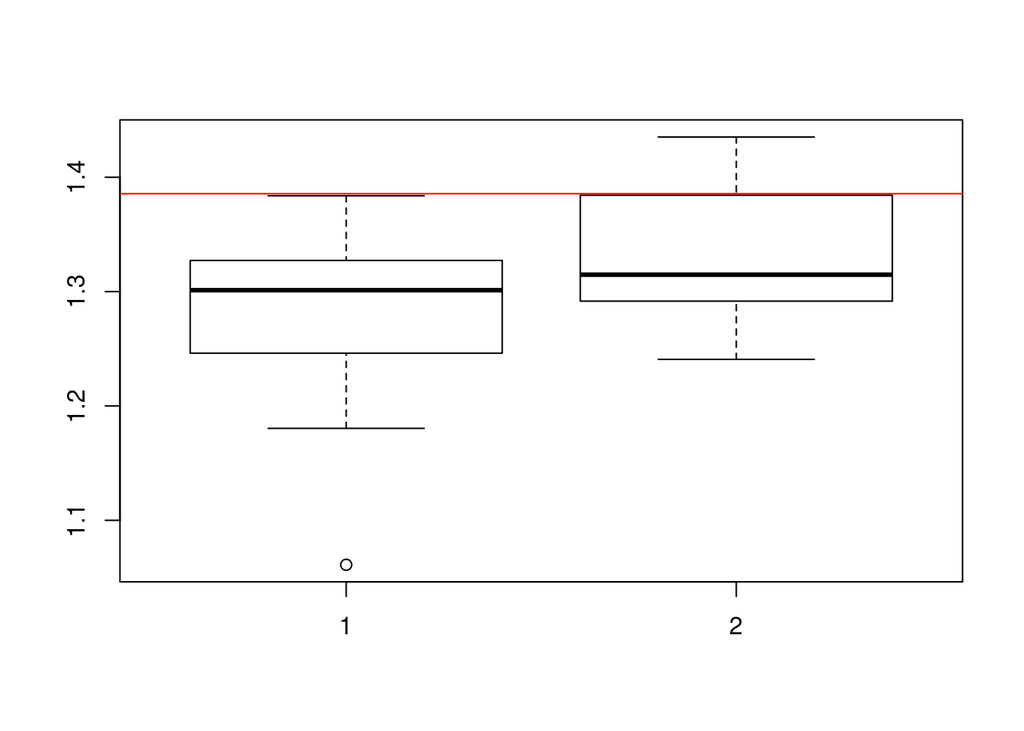

```r
boxplot(aode_ramen_eval1, aode_ramen_eval2)
abline(h=1.3856, col = "red") #this line can sometimes cause errors/warnings
```

Here is a naive Bayes for a comparasion with some baseline model.

```r
#table = confusion matrix, n = number of instances of test data
ramen_squared_error <- function(table, n) {
  error <- 0
  for (i in 1:4) {
    for (j in 1:4) {
      #print(error)
      #print(table[i,j])
      error <- (error + (table[i,j] * abs(i - j)))
    }
  }
  error <- error / n
  error
}

set.seed(123)
naive_ramen_evaluation <- function(iterations, splitPercentage ) {
  errors <- numeric(iterations)
  for (i in 1:iterations) {
    indicies <- createDataPartition(ramen_reviews$Rating, p = splitPercentage, list=FALSE)
    ramen_train <- ramen_reviews[indicies, ]
    ramen_test <- ramen_reviews[-indicies, ]

    naive_ramen_model <- naiveBayes(Rating ~ ., data = ramen_train)

    naive_ramen_prediction <- predict(naive_ramen_model, ramen_test)
    conf <- table(naive_ramen_prediction, ramen_test$Rating)
    errors[i] <- ramen_squared_error(conf, length(naive_ramen_prediction))
    cat("-", sep="") # just to see the progress of training
  }
  cat("\n")
  cat("Best error for split ratio" , splitPercentage, " : ", min(errors), "\n")
  errors
}
naive_ramen_eval1 <- naive_ramen_evaluation(15, 0.7)
```

```
## ---------------
## Best error for split ratio 0.7  :  0.911315
```

```r
naive_ramen_eval2 <- naive_ramen_evaluation(15, 0.95)
```

```
## ---------------
## Best error for split ratio 0.95  :  0.8611111
```

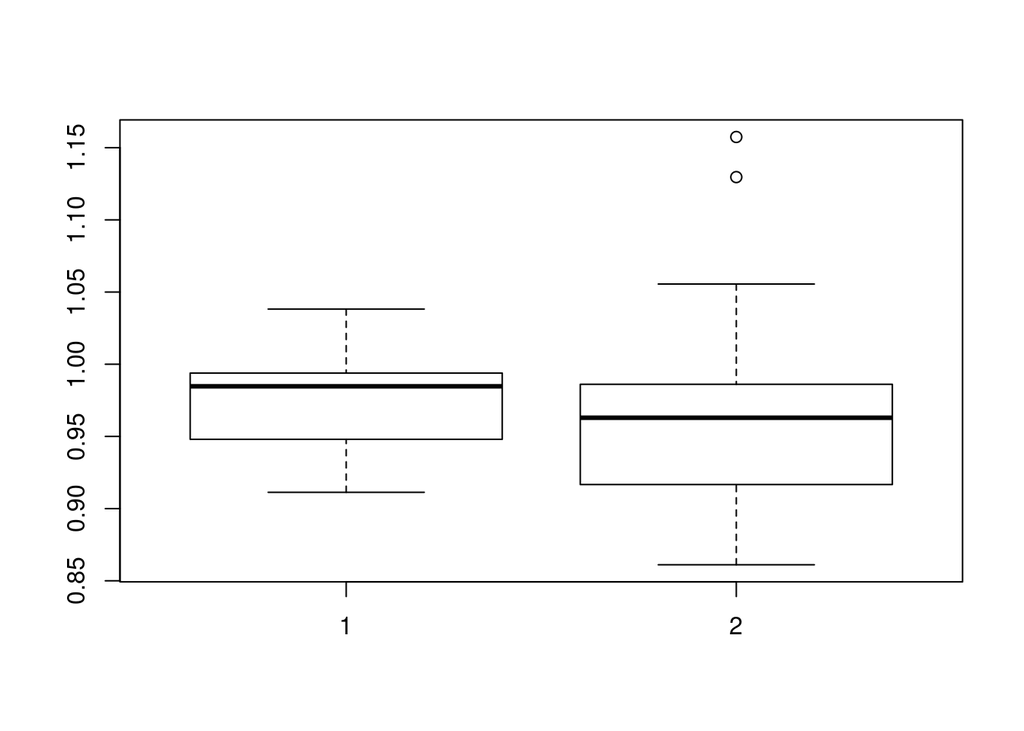

```r
boxplot(naive_ramen_eval1, naive_ramen_eval2)
abline(h=1.3856, col = "red") #this line can sometimes cause errors/warnings
```

#### 3. Student Performance

```r
set.seed(123)
aode_student_evaluation <- function(iterations, splitPercentage ) {
  accuracies <- numeric(iterations)
  for (i in 1:iterations) {
    indicies <- createDataPartition(student_performance$passed, p = splitPercentage, list=FALSE)
    student_train <- student_performance[indicies, ]
    student_test <- student_performance[-indicies, ]

    aode_student_model <- aode(student_train)

    aode_student_prediction <- predict(aode_student_model, student_test)
    conf <- table(aode_student_prediction, student_test$passed)
    accuracies[i] <- ((conf[1,1] + conf[2,2])/length(aode_student_prediction))
    cat("-", sep="") # just to see the progress of training
  }
  cat("\n")
  cat("Best accuracy for split ratio" , splitPercentage, " : ", max(accuracies), "\n")
  accuracies
}
suppressWarnings(aode_student_eval1 <- aode_student_evaluation(30, 0.7))
```

```
## ------------------------------
## Best accuracy for split ratio 0.7  :  0.7542373
```

```r
suppressWarnings(aode_student_eval2 <- aode_student_evaluation(30, 0.95))
```

```
## ------------------------------
## Best accuracy for split ratio 0.95  :  0.8947368
```

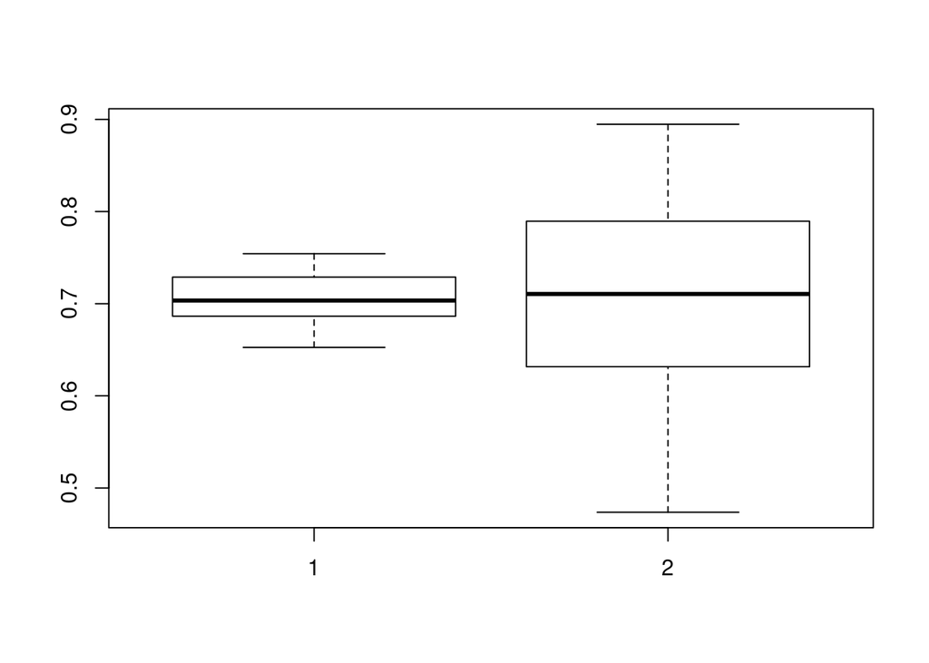

```r
boxplot(aode_student_eval1, aode_student_eval2)
```

## 6. Conclusion

### 1. German Credit Data

Bayesian Generalized Linear Model results : Within the scope 70%(train) 30%(test), best accuracy is around 0.7. On 95%(train) 5% test, best accuracy is around 0.75. The results are pretty poor. However the size of the dataset is not large and test set is really unbalanced(120/280 - bad/good). Therefore I think it gave us decent predictions.

### 2. Ramen Ratings

Initially I feared that this dataset might not have any correlation between the features and target class. Expected Ramen Squared Error of a random classifier is slightly above 2. Expected Ramen Squared Error of an optimal blind classifier (one which only knows the distribution of target classes) is roughly 1.3856.

With 95/5 split the results are abysmal, with Q3 almost touching optimal blind classifier, which means that 25% of results are worse. This could however be due to very small size of the test set.

## 7. References

https://archive.ics.uci.edu/ml/datasets/Statlog+%28German+Credit+Data%29  
https://www.kaggle.com/uciml/german-credit  
https://en.wikipedia.org/wiki/Generalized_linear_model